# Multiple comparisons & ANOVA, task N2

Natalia Sheiko

## A first glance at the data

```
##      Name                 Position       Nationality      Age
##  Length:150         Defender  :55   Argentinian:15   Min.   :18.0
##  Class :character   Forward   :30   English    :27   1st Qu.:23.0
##  Mode  :character   Goalkeeper:21   German     :25   Median :26.0
##                     Midfielder:44   Italian    :33   Mean   :26.5
##                                     Spanish    :50   3rd Qu.:30.0
##                                                      Max.   :38.0
##                                                      NA's   :4
##      Height
##  Min.   :165.0
##  1st Qu.:179.0
##  Median :183.0
##  Mean   :182.4
##  3rd Qu.:186.8
##  Max.   :201.0
##
```

## ANOVA for the differences among average height of soccer players on different field positions.

ANOVA requires three primary assumptions:

1. The responses for each factor level have a normal distribution.
2. The distributions for each factor level have the same variance.
3. The data are independent.

**Note that players on one position do not provide information about players on other position, so data are independent.**

### Data imbalance checking & normality testing

**H0:** the distribution of the data is not significantly different from normal distribution.

**H1:** the distribution of the data is significantly different from normal distribution.

| Position | variable | statistic | p.value | length(Height) | var(Height) | hypothesis accepted |
| --- | --- | --- | --- | --- | --- | --- |
| Defender | Height | 0.9646341 | 0.1051431 | 55 | 24.80337 | H0 |
| Forward | Height | 0.9518928 | 0.1899471 | 30 | 63.91379 | H0 |
| Goalkeeper | Height | 0.9511376 | 0.3578677 | 21 | 25.76190 | H0 |
| Midfielder | Height | 0.9695343 | 0.2913578 | 44 | 31.95349 | H0 |

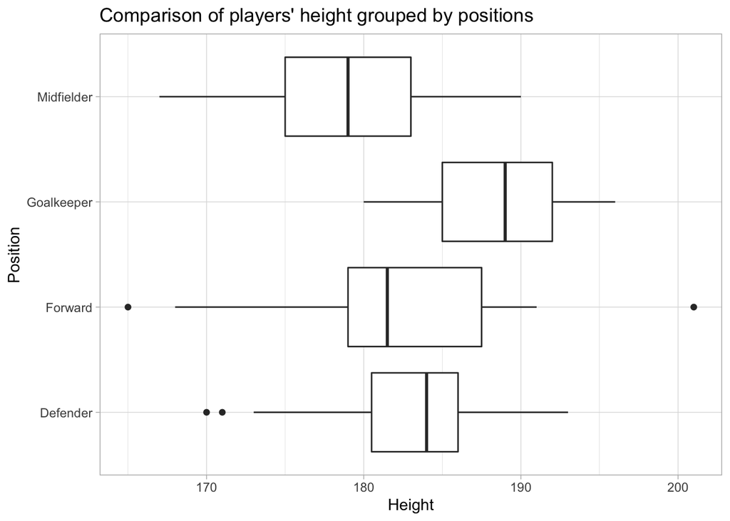

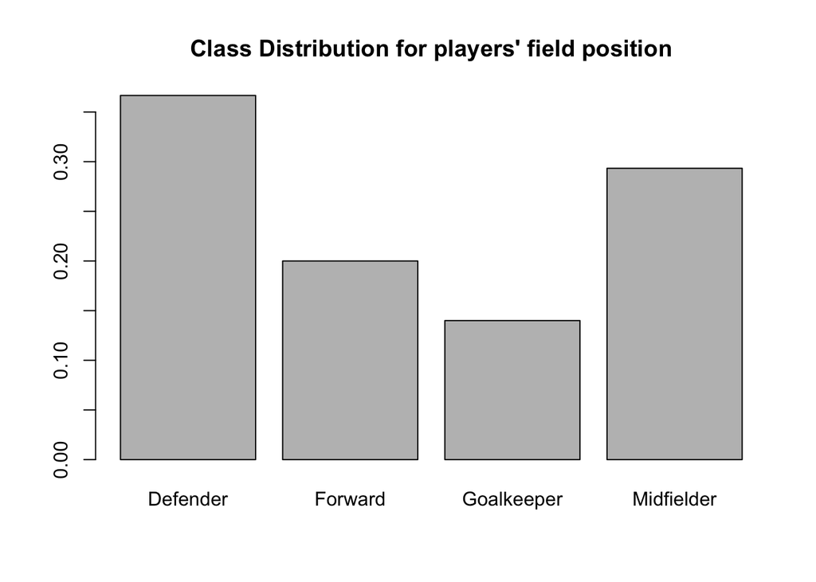

### Homoscedasticity checking

**H0:** the variances are equal for all positions (groups).

**H1:** the variances are not equal for one pair of positions (groups) or more.

We use Bartlett test to determine whether or not the variances between several groups are equal.

```
##
##  Bartlett test of homogeneity of variances
##
## data:  Height by Position
## Bartlett's K-squared = 10.243, df = 3, p-value = 0.01661
```

Since the p-value is less than 0.05, we can reject the null hypothesis.

**Conclusion:**

*… therefore we can proceed to perform the one-way ANOVA.*

### One-way ANOVA

**H0:** there is no difference among players’ height on different field positions

**H1:** there is a difference between players’ height for one pair of field positions or more.

```
##
##  One-way analysis of means (not assuming equal variances)
##
## data:  Height and Position
## F = 15.44, num df = 3.00, denom df = 62.23, p-value = 1.288e-07
```

Since the p-value is less than 0.05, we can reject the null hypothesis.

There is a difference between players’ height for some pair/pairs of field positions. To detect this pairs we can perform a post hoc analysis with Hothorn-Bretz-Westfall procedure

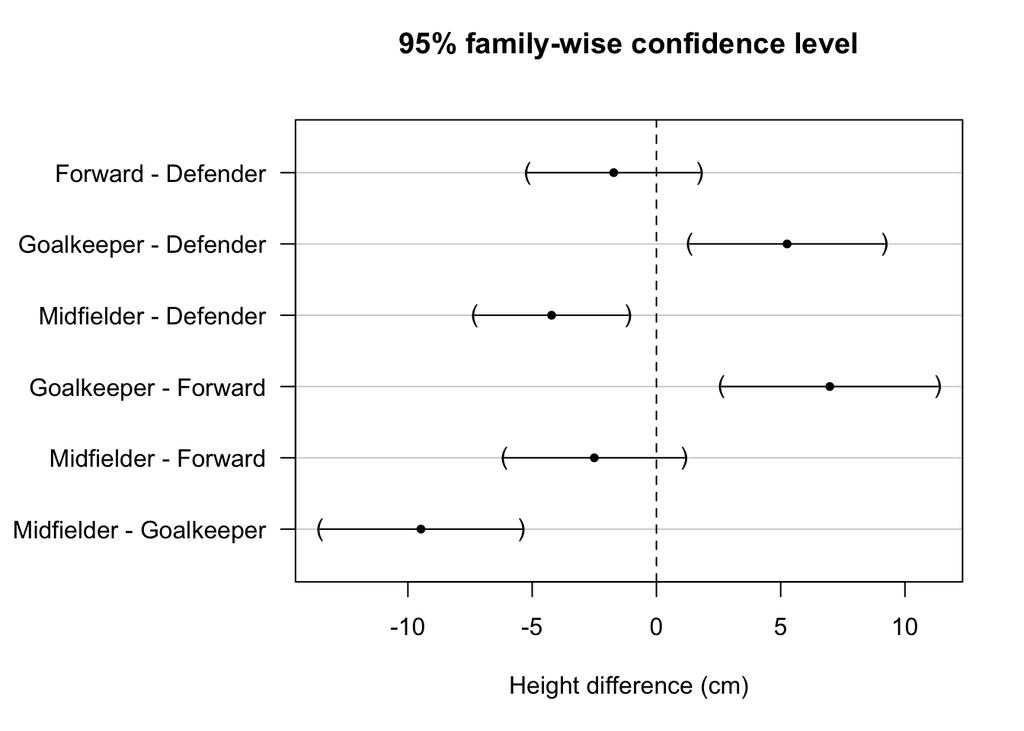

```
##
##   Simultaneous Tests for General Linear Hypotheses
##
## Multiple Comparisons of Means: Tukey Contrasts
##
##
## Fit: lm(formula = Height ~ Position, data = soccer_wrk)
##
## Linear Hypotheses:
##                              Estimate Std. Error t value Pr(>|t|)
## Forward - Defender == 0        -1.718      1.339  -1.283  0.57138
## Goalkeeper - Defender == 0      5.258      1.513   3.474  0.00366 **
## Midfielder - Defender == 0     -4.218      1.193  -3.535  0.00297 **
## Goalkeeper - Forward == 0       6.976      1.679   4.156  < 0.001 ***
## Midfielder - Forward == 0      -2.500      1.397  -1.790  0.27918
## Midfielder - Goalkeeper == 0   -9.476      1.565  -6.056  < 0.001 ***
## ---
## Signif. codes:  0 '***' 0.001 '**' 0.01 '*' 0.05 '.' 0.1 ' ' 1
## (Adjusted p values reported -- single-step method)
##
##
##   Simultaneous Confidence Intervals
##
## Multiple Comparisons of Means: Tukey Contrasts
##
##
## Fit: lm(formula = Height ~ Position, data = soccer_wrk)
##
## Quantile = 2.5918
## 95% family-wise confidence level
##
##
## Linear Hypotheses:
##                              Estimate lwr      upr
## Forward - Defender == 0       -1.7182  -5.1889   1.7525
## Goalkeeper - Defender == 0     5.2580   1.3355   9.1806
## Midfielder - Defender == 0    -4.2182  -7.3111  -1.1253
## Goalkeeper - Forward == 0      6.9762   2.6254  11.3270
## Midfielder - Forward == 0     -2.5000  -6.1206   1.1206
## Midfielder - Goalkeeper == 0  -9.4762 -13.5320  -5.4204
```

So we can conclude that there is significant difference between height of players on this field positions:

- Goalkeeper - Defender
- Midfielder - Defender
- Goalkeeper - Forward
- Midfielder - Goalkeeper

The hometask N1 leads to another conclusion: there was significant differences only between this positions:

- Defender - Forward
- Forward - Midfielder

## ANOVA for the differences among average height of soccer players of different countries.

In general, the process is the same as in the example above.

**Players from one country do not provide information about other players’ countries, so data are independent.**

### Data imbalance checking & normality testing

**H0:** the distribution of the data is not significantly different from normal distribution.

**H1:** the distribution of the data is significantly different from normal distribution.

| Nationality | variable | statistic | p.value | length(Height) | var(Height) | hypothesis accepted |
| --- | --- | --- | --- | --- | --- | --- |
| Argentinian | Height | 0.9604474 | 0.70017392 | 15 | 40.49524 | H0 |
| English | Height | 0.9719038 | 0.65273628 | 27 | 48.87179 | H0 |
| German | Height | 0.9566672 | 0.35210294 | 25 | 64.74333 | H0 |
| Italian | Height | 0.9481316 | 0.11732698 | 33 | 25.32008 | H0 |
| Spanish | Height | 0.9515375 | 0.03946918 | 50 | 42.06694 | H1 |

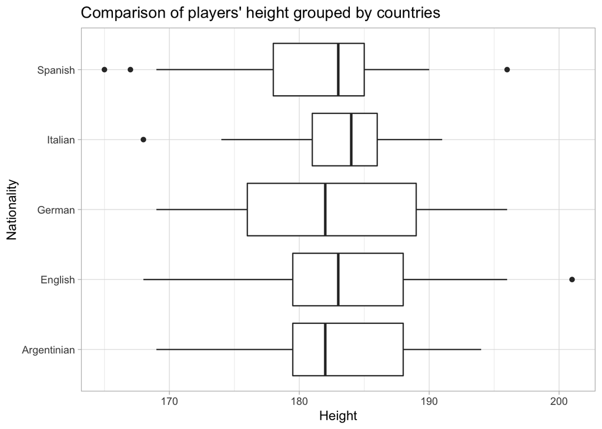

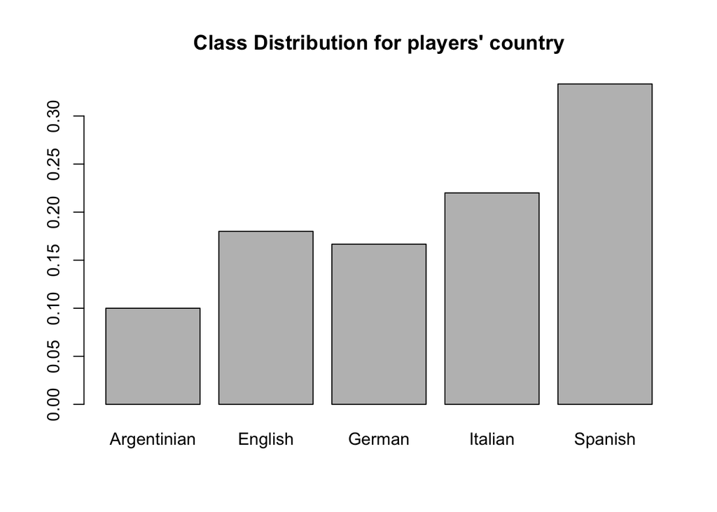

### Homoscedasticity checking

**H0:** the variances are equal for all positions (groups).

**H1:** the variances are not equal for one pair of positions (groups) or more.

We use Bartlett test to determine whether or not the variances between several groups are equal.

```
##
##  Bartlett test of homogeneity of variances
##
## data:  Height by Nationality
## Bartlett's K-squared = 6.2594, df = 4, p-value = 0.1806
```

Since the p-value is more than 0.05, we can’t reject the null hypothesis.

**Conclusion:**

*… therefore we can proceed to perform general ANOVA (F-test).*

### ANOVA

**H0:** there is no difference among average height of players from different countries

**H1:** there is a difference among average height of players from different countries

```
##              Df Sum Sq Mean Sq F value Pr(>F)
## Nationality   4    164   41.03    0.95  0.437
## Residuals   145   6263   43.19
```

Since the p-value is more than 0.05, we can’t reject the null hypothesis.

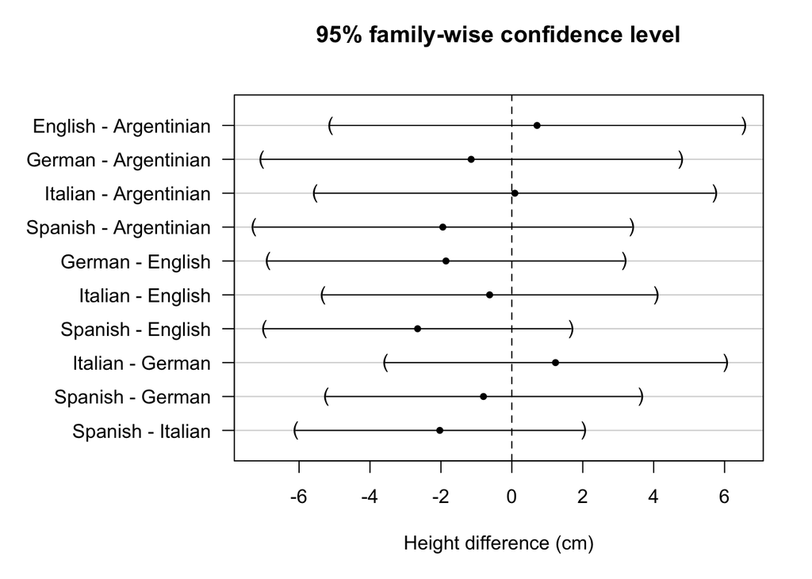

```
##
##   Simultaneous Tests for General Linear Hypotheses
##
## Multiple Comparisons of Means: Tukey Contrasts
##
##
## Fit: lm(formula = Height ~ Nationality, data = soccer_wrk)
##
## Linear Hypotheses:
##                            Estimate Std. Error t value Pr(>|t|)
## English - Argentinian == 0  0.71111    2.11643   0.336    0.997
## German - Argentinian == 0  -1.14667    2.14645  -0.534    0.983
## Italian - Argentinian == 0  0.08485    2.04656   0.041    1.000
## Spanish - Argentinian == 0 -1.94667    1.93478  -1.006    0.849
## German - English == 0      -1.85778    1.82413  -1.018    0.844
## Italian - English == 0     -0.62626    1.70546  -0.367    0.996
## Spanish - English == 0     -2.65778    1.56958  -1.693    0.436
## Italian - German == 0       1.23152    1.74258   0.707    0.954
## Spanish - German == 0      -0.80000    1.60984  -0.497    0.987
## Spanish - Italian == 0     -2.03152    1.47402  -1.378    0.638
## (Adjusted p values reported -- single-step method)
##
##
##   Simultaneous Confidence Intervals
##
## Multiple Comparisons of Means: Tukey Contrasts
##
##
## Fit: lm(formula = Height ~ Nationality, data = soccer_wrk)
##
## Quantile = 2.7526
## 95% family-wise confidence level
##
##
## Linear Hypotheses:
##                            Estimate lwr      upr
## English - Argentinian == 0  0.71111 -5.11466  6.53688
## German - Argentinian == 0  -1.14667 -7.05508  4.76174
## Italian - Argentinian == 0  0.08485 -5.54860  5.71830
## Spanish - Argentinian == 0 -1.94667 -7.27244  3.37910
## German - English == 0      -1.85778 -6.87896  3.16341
## Italian - English == 0     -0.62626 -5.32080  4.06828
## Spanish - English == 0     -2.65778 -6.97829  1.66273
## Italian - German == 0       1.23152 -3.56519  6.02822
## Spanish - German == 0      -0.80000 -5.23131  3.63131
## Spanish - Italian == 0     -2.03152 -6.08897  2.02594
```

**Conclusion:** We can conclude that there is no significant difference between height of players from different countries.